# Target a subsidy

### CV Goodness of Fit Metrics

Figure 9 and figure 10 plot the distribution of AUC, Sensitivity, and Specificity of kitchen sink and engineering model. Both the model is not tight enough to the mean, so both models are not generalizable, The sensitivity for both models generalizes better than AUC and Specificity. The AUC distributes seperately around the mean, while specificity was overfit with 0.5.

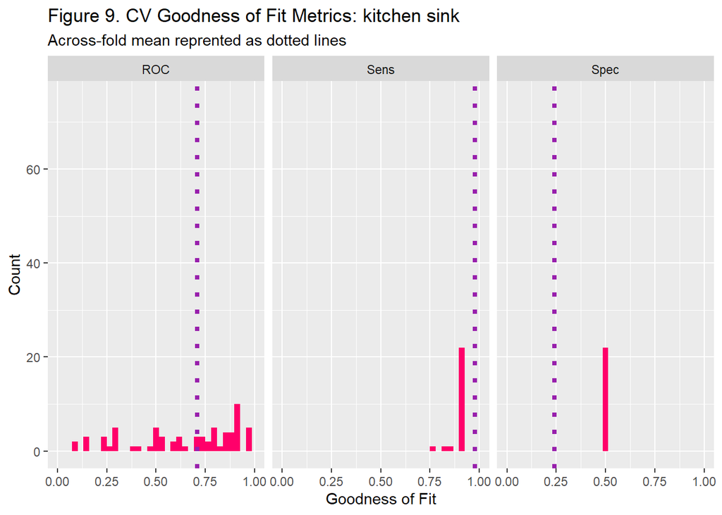

```r
#CV Goodness of Fit Metrics: kitchen sink
dplyr::select(kitchen.cvFit$resample, -Resample) %>%
  gather(metric, value) %>%
  left_join(gather(kitchen.cvFit$results[2:4], metric, mean)) %>%
  ggplot(aes(value)) +
  geom_histogram(bins=35, fill = "#FF006A") +
  facet_wrap(~metric) +
  geom_vline(aes(xintercept = mean), colour = "#981FAC", linetype = 3, size = 1.5) +
  scale_x_continuous(limits = c(0, 1)) +
  labs(x="Goodness of Fit", y="Count", title="Figure 9. CV Goodness of Fit Metrics: kitchen sink",
       subtitle = "Across-fold mean reprented as dotted lines")
```

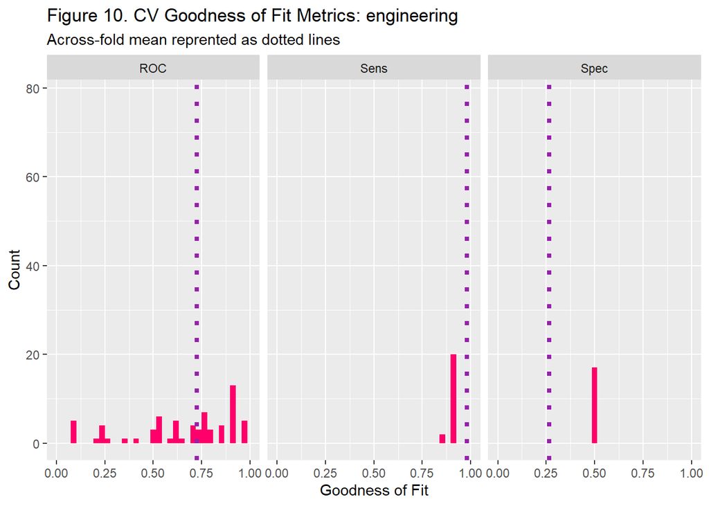

```r
#CV Goodness of Fit Metrics: engineering
dplyr::select(eng.cvFit$resample, -Resample) %>%
  gather(metric, value) %>%
  left_join(gather(eng.cvFit$results[2:4], metric, mean)) %>%
  ggplot(aes(value)) +
  geom_histogram(bins=35, fill = "#FF006A") +
  facet_wrap(~metric) +
  geom_vline(aes(xintercept = mean), colour = "#981FAC", linetype = 3, size = 1.5) +
  scale_x_continuous(limits = c(0, 1)) +
  labs(x="Goodness of Fit", y="Count", title="Figure 10. CV Goodness of Fit Metrics: engineering",
       subtitle = "Across-fold mean reprented as dotted lines")
```

Despite the engineer model does not differ much from the kitchen sink model, we still choose the engineer model for its better performance (higher accuracy, sensitivity and specificity) and based on that, conduct cost benefit analysis.